# Determination Size at Maturity

Selected species of tuna and tuna-like fish in Somalia Water

Author

Rushingisha George, Masumbuko Semba, and Mathew Silas

Published

December 16, 2025

Modified

December 19, 2025

**What we’re doing:** Load the R packages required for maturity analysis and data visualization.

```r
# Load required libraries
library(tidyverse)      # Data manipulation and visualization
library(sizeMat)        # For morphological maturity analysis
library(gt)             # For professional tables
require(TropFishR)      # Tropical fisheries methods (if needed)
```

# Introduction

This document serves as a step-by-step exercise to determine the size at maturity (L50) for several commercially important fish species in Somalia. We will use a morphological method, which classifies fish as mature or immature based on their length-weight relationship.

The exercise will proceed as follows:

# Method

## Data Preparation

**What we’re doing:** Load the fisheries dataset containing length and weight measurements for various fish species.

```r
lw = read_csv("lw2.csv")
```

### Identify Species with Sufficient Data

**Why it matters:** Species with few observations produce unreliable estimates. Focusing on well-sampled species ensures robust maturity determinations.

```r
fishes = lw |>
  group_by(fish_type_code) |>
  tally() |>
  arrange(desc(n)) |>
  filter(n > 200) |>
  pull(fish_type_code)

# Use these key tuna and mackerel species
fishes = c("YFT", "SKJ", "KAW", "JAC", "LOT", "MAH", "SCH", "BET")
```

### Create Species Reference Table

**What we’re doing:** Build a lookup table mapping FAO species codes to common and scientific names.

**Why it matters:** Clear species identification ensures accurate communication and proper interpretation of results.

```r
fish_name <- tibble(
  FAO_Code = c("YFT", "SKJ", "KAW", "JAC", "LOT", "MAH", "SCH", "BET"),
  English_Name = c("Yellowfin tuna", "Skipjack tuna", "Kawakawa", "Jack mackerel",
                   "Longtail tuna", "Mahi-mahi", "Chub mackerel", "Bigeye tuna"),
  Scientific_Name = c("Thunnus albacares", "Katsuwonus pelamis", "Euthynnus affinis",
                      "Trachurus spp.", "Thunnus tonggol", "Coryphaena hippurus",
                      "Scomber japonicus", "Thunnus obesus")
)

fish_name
```

```
# A tibble: 8 × 3
  FAO_Code English_Name   Scientific_Name
  <chr>    <chr>          <chr>
1 YFT      Yellowfin tuna Thunnus albacares
2 SKJ      Skipjack tuna  Katsuwonus pelamis
3 KAW      Kawakawa       Euthynnus affinis
4 JAC      Jack mackerel  Trachurus spp.
5 LOT      Longtail tuna  Thunnus tonggol
6 MAH      Mahi-mahi      Coryphaena hippurus
7 SCH      Chub mackerel  Scomber japonicus
8 BET      Bigeye tuna    Thunnus obesus
```

### Inspect Dataset Structure

**What we’re doing:** Display the column names and data types in the dataset.

**What to look for:** Ensure date, length, weight, and species columns are present and correctly formatted.

```r
lw |>
    glimpse()
```

```
Rows: 3,571
Columns: 19
$ boat_id              <dbl> 1, 1, 1, 1, 1, 1, 2, 2, 2, 2, 2, 2, 2, 2, 3, 3, 3…
$ catch_id             <dbl> 1, 1, 1, 1, 1, 3, 7, 7, 7, 4, 4, 5, 5, 5, 9, 9, 9…
$ fish_id              <dbl> 1, 2, 3, 4, 5, 6, 7, 8, 9, 10, 11, 12, 13, 14, 15…
$ date_dd_mm_yy        <dttm> 2018-11-02, 2018-11-02, 2018-11-02, 2018-11-02, …
$ year                 <dbl> 2018, 2018, 2018, 2018, 2018, 2018, 2018, 2018, 2…
$ month                <chr> "Nov", "Nov", "Nov", "Nov", "Nov", "Nov", "Nov", …
$ day                  <dbl> 2, 2, 2, 2, 2, 2, 2, 2, 2, 2, 2, 2, 2, 2, 2, 2, 2…
$ region               <chr> "Mogadishu", "Mogadishu", "Mogadishu", "Mogadishu…
$ landing_site         <chr> "Lido Beach", "Lido Beach", "Lido Beach", "Lido B…
$ vessel_id            <dbl> 1, 1, 1, 1, 1, 1, 2, 2, 2, 2, 2, 2, 2, 2, 3, 3, 3…
$ fish_type_code       <chr> "YFT", "YFT", "YFT", "YFT", "YFT", "MAH", "OTH1",…
$ fish_index           <dbl> 1, 2, 3, 4, 5, 1, 1, 2, 3, 1, 2, 1, 2, 3, 1, 2, 3…
$ weight_kg            <dbl> 7.7, 3.6, 4.5, 4.5, 3.2, 9.5, 2.3, 3.2, 2.3, 11.0…
$ length_cm            <dbl> 76, 59, 65, 67, 61, 124, 55, 64, 55, 84, 85, 62, …
$ fish_group           <chr> "Tuna", "Tuna", "Tuna", "Tuna", "Tuna", "Other", …
$ notes                <chr> NA, NA, NA, NA, NA, NA, "Aarjoog", "Aarjoog", "Aa…
$ kobo_section_1_index <lgl> NA, NA, NA, NA, NA, NA, NA, NA, NA, NA, NA, NA, N…
$ kobo_section_2_index <lgl> NA, NA, NA, NA, NA, NA, NA, NA, NA, NA, NA, NA, N…
$ kobo_section_3_index <lgl> NA, NA, NA, NA, NA, NA, NA, NA, NA, NA, NA, NA, N…
```

## Fish Groups Analysis

In the following sections, we will perform the size-at-maturity analysis for several key tuna and mackerel species. For each species, we: 1. Filter the data to that species 2. Classify fish as mature or immature using morphological criteria 3. Model the maturity ogive to estimate L50 (length at 50% maturity)

### Yellowfin Tuna

**What we’re doing:** Filter the dataset to create a subset containing only Yellowfin Tuna (YFT).

**Why start here:** Yellowfin is a well-studied, commercially important species with good sample sizes.

```r
yft = lw |>
    filter(fish_type_code == 'YFT')
```

### Maturity Classification using Linear Discriminant Analysis

**What we’re doing:** Use the `classify_mature()` function to separate fish into mature and immature groups based on their length-weight relationship.

**How it works:** - Linear discriminant analysis (LDA) finds the boundary that best separates mature from immature fish in length-weight space - Creates a new `mature` column indicating classification for each fish - Works best when there’s a clear separation between groups in the data

**Why it matters:** This classification is the foundation for the subsequent ogive fitting and L50 estimation.

```r
## Partitioning with Linear Discriminant Analysis
classified_yft <- yft |>
  classify_mature(
    varNames = c("length_cm", "weight_kg"),  # Variables to use for classification
    varSex = NULL,                            # No sex data available
    selectSex = NULL,
    method = "ld"                             # Linear discriminant method
  )
```

```
all individuals were used in the analysis
```

```r
classified_yft
```

```
Number in juvenile group = 384

Number in adult group = 94

--------------------------------------------------------
1) Linear regression for juveniles

Call:
glm(formula = y ~ x, data = juv)

Coefficients:
             Estimate Std. Error t value Pr(>|t|)
(Intercept) -7.322622   0.461709  -15.86   <2e-16 ***
x            0.197443   0.006518   30.29   <2e-16 ***
---
Signif. codes:  0 '***' 0.001 '**' 0.01 '*' 0.05 '.' 0.1 ' ' 1

(Dispersion parameter for gaussian family taken to be 2.400289)

    Null deviance: 3119.30  on 383  degrees of freedom
Residual deviance:  916.91  on 382  degrees of freedom
AIC: 1430

Number of Fisher Scoring iterations: 2

--------------------------------------------------------
2) Linear regression for adults

Call:
glm(formula = y ~ x, data = adt)

Coefficients:
             Estimate Std. Error t value Pr(>|t|)
(Intercept) -65.60758    6.34616  -10.34   <2e-16 ***
x             0.82557    0.05265   15.68   <2e-16 ***
---
Signif. codes:  0 '***' 0.001 '**' 0.01 '*' 0.05 '.' 0.1 ' ' 1

(Dispersion parameter for gaussian family taken to be 127.6477)

    Null deviance: 43126  on 93  degrees of freedom
Residual deviance: 11744  on 92  degrees of freedom
AIC: 726.57

Number of Fisher Scoring iterations: 2

--------------------------------------------------------
3) Difference between slopes (ANCOVA)
               Estimate Std. Error    t value     Pr(>|t|)
(Intercept)  -7.3226224 1.54018587  -4.754376 2.644698e-06
x             0.1974434 0.02174360   9.080530 2.922047e-18
mature      -58.2849588 3.28623457 -17.736092 2.346836e-54
x:mature      0.6281301 0.03244821  19.357928 6.044495e-62
[1] "slopes are different"
```

### Visualize Classification Results

**What we’re doing:** Plot the classified fish on a length-weight scatter plot to visually inspect classification quality.

**What to look for:** - Clear spatial separation between mature (upper right) and immature (lower left) groups - Few misclassified points in the overlap region - Good coverage of the entire range

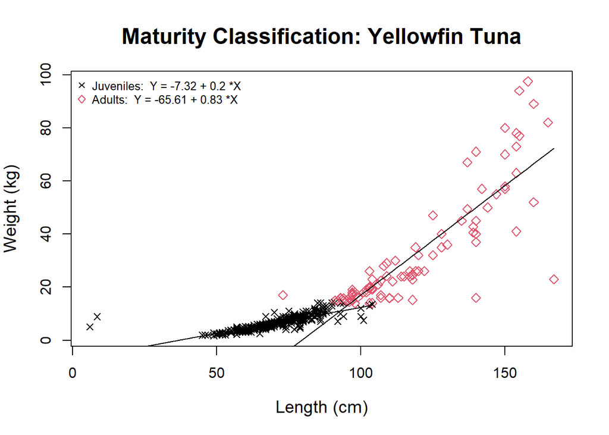

```r
classified_yft |>
  plot(
    main = 'Maturity Classification: Yellowfin Tuna',
    xlab = 'Length (cm)',
    ylab = 'Weight (kg)',
    cex.main = 1.5,
    cex.lab = 1.2,
    cex.axis = 1
  )
```

### Fit Maturity Ogive

**What we’re doing:** Model the maturity classification with a logistic regression curve using 1000 bootstrap samples.

**Why 1000 iterations:** Bootstrap resampling with 1000 iterations provides stable estimates and quantifies uncertainty in L50.

```r
yft_ogive_fq <- classified_yft |>
  morph_mature(
    method = "fq",      # Frequentist method using logistic regression
    niter = 1000        # 1000 bootstrap samples for stable estimates
  )
```

### Plot Maturity Ogive

**What we’re doing:** Display the fitted maturity curve showing the proportion of mature fish at each length.

**What it shows:** - X-axis: Length (cm) - Y-axis: Proportion of mature individuals (0 to 1) - S-shaped curve typical of logistic maturity schedules - L50 is where the curve crosses 0.5 (50% maturity)

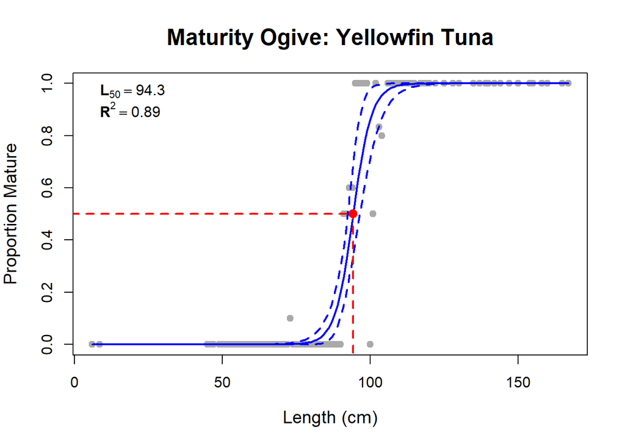

```
Size at morphometric maturity = 94.3
Confidence intervals = 92.4 - 96.5
Rsquare = 0.89
```

```r
yft_ogive_fq |>
    plot(
    main = 'Maturity Ogive: Yellowfin Tuna',
    xlab = 'Length (cm)',
    ylab = 'Proportion Mature',
    cex.main = 1.5,
    cex.lab = 1.2,
    cex.axis = 1,
    onlyOgive = TRUE
  )
```

### Bigeye Tuna

**What we’re doing:** Repeat the maturity analysis for Bigeye Tuna (BET).

```r
bigeye = lw |>
    filter(fish_type_code == 'BET')
```

```r
## Partitioning with Linear Discriminant Analysis
classified_bet <- bigeye |>
  classify_mature(
    varNames = c("length_cm", "weight_kg"),
    varSex = NULL,
    selectSex = NULL,
    method = "ld"
  )
```

```
all individuals were used in the analysis
```

```r
classified_bet
```

```
Number in juvenile group = 47

Number in adult group = 54

--------------------------------------------------------
1) Linear regression for juveniles

Call:
glm(formula = y ~ x, data = juv)

Coefficients:
            Estimate Std. Error t value Pr(>|t|)
(Intercept) -6.89259    1.40281  -4.913 1.23e-05 ***
x            0.18478    0.02499   7.395 2.66e-09 ***
---
Signif. codes:  0 '***' 0.001 '**' 0.01 '*' 0.05 '.' 0.1 ' ' 1

(Dispersion parameter for gaussian family taken to be 0.535058)

    Null deviance: 53.337  on 46  degrees of freedom
Residual deviance: 24.078  on 45  degrees of freedom
AIC: 107.94

Number of Fisher Scoring iterations: 2

--------------------------------------------------------
2) Linear regression for adults

Call:
glm(formula = y ~ x, data = adt)

Coefficients:
            Estimate Std. Error t value Pr(>|t|)
(Intercept) -6.66096    1.37579  -4.842 1.20e-05 ***
x            0.17479    0.01749   9.991 1.07e-13 ***
---
Signif. codes:  0 '***' 0.001 '**' 0.01 '*' 0.05 '.' 0.1 ' ' 1

(Dispersion parameter for gaussian family taken to be 2.378245)

    Null deviance: 361.08  on 53  degrees of freedom
Residual deviance: 123.67  on 52  degrees of freedom
AIC: 203.99

Number of Fisher Scoring iterations: 2

--------------------------------------------------------
3) Difference between slopes (ANCOVA)
                Estimate Std. Error     t value     Pr(>|t|)
(Intercept) -6.892589006 2.36684783 -2.91213864 4.454437e-03
x            0.184778291 0.04215873  4.38291908 2.968382e-05
mature       0.231624336 2.61040596  0.08873115 9.294785e-01
x:mature    -0.009988657 0.04442261 -0.22485527 8.225649e-01
[1] "slopes are the same"
```

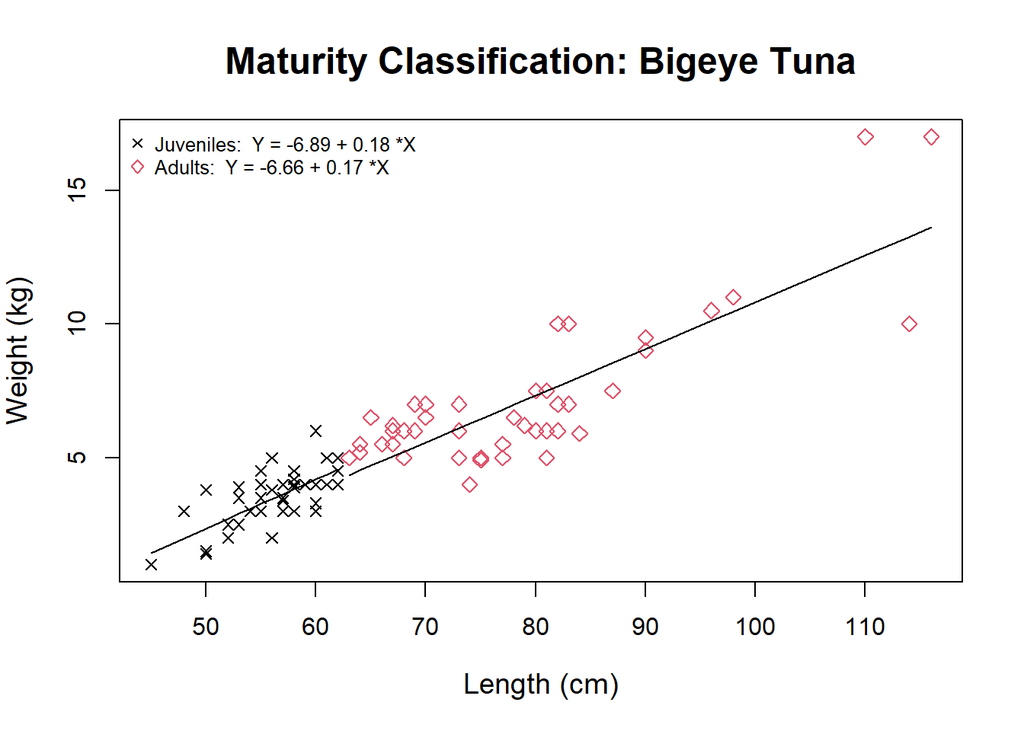

```r
classified_bet |>
  plot(
    main = 'Maturity Classification: Bigeye Tuna',
    xlab = 'Length (cm)',
    ylab = 'Weight (kg)',
    cex.main = 1.5,
    cex.lab = 1.2,
    cex.axis = 1
  )
```

```r
bet_ogive_fq <- morph_mature(
    data = classified_bet,
    method = "fq",
    niter = 1000
)
```

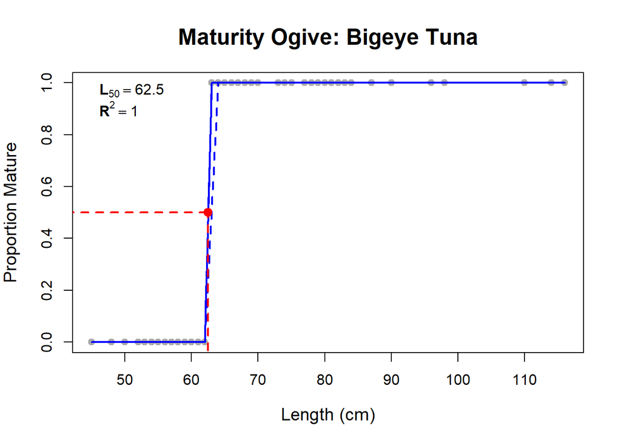

```
Size at morphometric maturity = 62.5
Confidence intervals = 62.5 - 63
Rsquare = 1
```

```r
bet_ogive_fq |>
    plot(
    main = 'Maturity Ogive: Bigeye Tuna',
    xlab = 'Length (cm)',
    ylab = 'Proportion Mature',
    cex.main = 1.5,
    cex.lab = 1.2,
    cex.axis = 1,
    onlyOgive = TRUE
)
```

### Skipjack Tuna

**What we’re doing:** Analyze maturity for Skipjack Tuna (SKJ).

```r
skj = lw |>
    filter(fish_type_code == 'SKJ')
```

```r
## Partitioning with Linear Discriminant Analysis
classified_skj <- skj |>
  classify_mature(
    varNames = c("length_cm", "weight_kg"),
    varSex = NULL,
    selectSex = NULL,
    method = "ld"
  )
```

```
all individuals were used in the analysis
```

```r
classified_skj
```

```
Number in juvenile group = 177

Number in adult group = 242

--------------------------------------------------------
1) Linear regression for juveniles

Call:
glm(formula = y ~ x, data = juv)

Coefficients:
            Estimate Std. Error t value Pr(>|t|)
(Intercept) 12.76290    4.21026   3.031   0.0028 **
x           -0.07542    0.06164  -1.224   0.2227
---
Signif. codes:  0 '***' 0.001 '**' 0.01 '*' 0.05 '.' 0.1 ' ' 1

(Dispersion parameter for gaussian family taken to be 57.13805)

    Null deviance: 10084.7  on 176  degrees of freedom
Residual deviance:  9999.2  on 175  degrees of freedom
AIC: 1222.3

Number of Fisher Scoring iterations: 2

--------------------------------------------------------
2) Linear regression for adults

Call:
glm(formula = y ~ x, data = adt)

Coefficients:
             Estimate Std. Error t value Pr(>|t|)
(Intercept) -0.295127   0.450985  -0.654    0.513
x            0.061606   0.008485   7.261 5.33e-12 ***
---
Signif. codes:  0 '***' 0.001 '**' 0.01 '*' 0.05 '.' 0.1 ' ' 1

(Dispersion parameter for gaussian family taken to be 0.313259)

    Null deviance: 91.698  on 241  degrees of freedom
Residual deviance: 75.182  on 240  degrees of freedom
AIC: 409.86

Number of Fisher Scoring iterations: 2

--------------------------------------------------------
3) Difference between slopes (ANCOVA)
                Estimate Std. Error   t value     Pr(>|t|)
(Intercept)  12.76290452 2.74429465  4.650705 4.453582e-06
x            -0.07542021 0.04017504 -1.877290 6.117953e-02
mature      -13.05803195 4.82621335 -2.705647 7.098057e-03
x:mature      0.13702593 0.08480911  1.615698 1.069195e-01
[1] "slopes are the same"
```

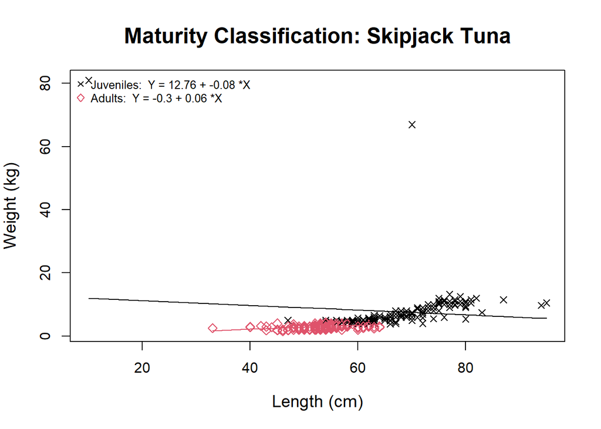

```r
classified_skj |>
  plot(
    main = 'Maturity Classification: Skipjack Tuna',
    xlab = 'Length (cm)',
    ylab = 'Weight (kg)',
    cex.main = 1.5,
    cex.lab = 1.2,
    cex.axis = 1
  )
```

```r
skj_ogive_fq <- morph_mature(
    data = classified_skj,
    method = "fq",
    niter = 1000
)
```

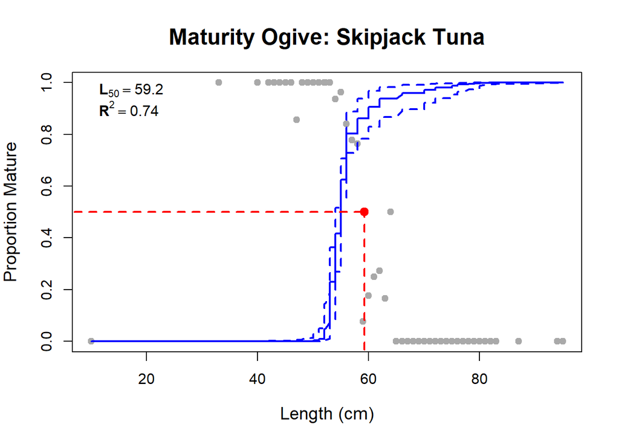

```
Size at morphometric maturity = 59.2
Confidence intervals = 58.4 - 60.2
Rsquare = 0.74
```

```r
skj_ogive_fq |>
    plot(
    main = 'Maturity Ogive: Skipjack Tuna',
    xlab = 'Length (cm)',
    ylab = 'Proportion Mature',
    cex.main = 1.5,
    cex.lab = 1.2,
    cex.axis = 1,
    onlyOgive = TRUE
)
```

### Kawakawa

**What we’re doing:** Analyze maturity for Kawakawa (KAW).

```r
kaw = lw |>
    filter(fish_type_code == 'KAW')
```

```r
## Partitioning with Linear Discriminant Analysis
classified_kaw <- kaw |>
  classify_mature(
    varNames = c("length_cm", "weight_kg"),
    varSex = NULL,
    selectSex = NULL,
    method = "ld"
  )
```

```
all individuals were used in the analysis
```

```r
classified_kaw
```

```
Number in juvenile group = 221

Number in adult group = 88

--------------------------------------------------------
1) Linear regression for juveniles

Call:
glm(formula = y ~ x, data = juv)

Coefficients:
            Estimate Std. Error t value Pr(>|t|)
(Intercept) 19.52081    2.25452   8.659 1.05e-15 ***
x           -0.26208    0.03768  -6.955 4.01e-11 ***
---
Signif. codes:  0 '***' 0.001 '**' 0.01 '*' 0.05 '.' 0.1 ' ' 1

(Dispersion parameter for gaussian family taken to be 12.82692)

    Null deviance: 3429.6  on 220  degrees of freedom
Residual deviance: 2809.1  on 219  degrees of freedom
AIC: 1195.1

Number of Fisher Scoring iterations: 2

--------------------------------------------------------
2) Linear regression for adults

Call:
glm(formula = y ~ x, data = adt)

Coefficients:
            Estimate Std. Error t value Pr(>|t|)
(Intercept) 0.943610   0.316189   2.984  0.00370 **
x           0.019815   0.006459   3.068  0.00289 **
---
Signif. codes:  0 '***' 0.001 '**' 0.01 '*' 0.05 '.' 0.1 ' ' 1

(Dispersion parameter for gaussian family taken to be 0.162647)

    Null deviance: 15.518  on 87  degrees of freedom
Residual deviance: 13.988  on 86  degrees of freedom
AIC: 93.887

Number of Fisher Scoring iterations: 2

--------------------------------------------------------
3) Difference between slopes (ANCOVA)
               Estimate Std. Error   t value     Pr(>|t|)
(Intercept)  19.5208105 1.91515989 10.192784 3.452735e-21
x            -0.2620805 0.03200910 -8.187688 7.353140e-15
mature      -18.5772002 3.05896897 -6.073027 3.729322e-09
x:mature      0.2818955 0.05830129  4.835150 2.113165e-06
[1] "slopes are different"
```

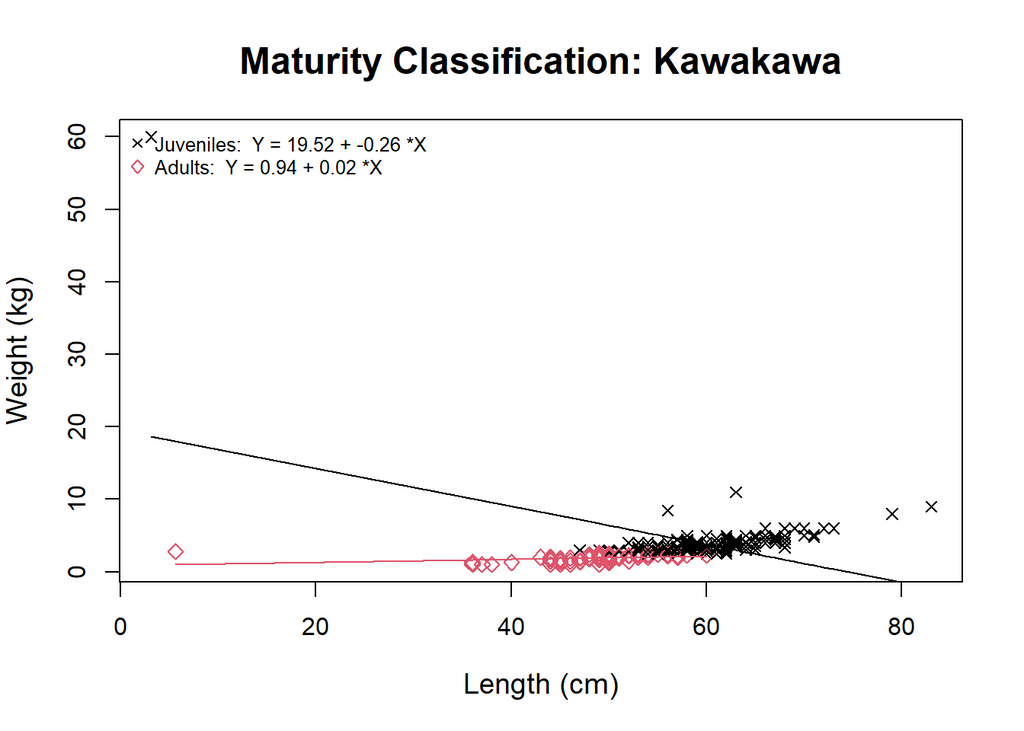

```r
classified_kaw |>
  plot(
    main = 'Maturity Classification: Kawakawa',
    xlab = 'Length (cm)',
    ylab = 'Weight (kg)',
    cex.main = 1.5,
    cex.lab = 1.2,
    cex.axis = 1
  )
```

```r
kaw_ogive_fq <- morph_mature(
    data = classified_kaw,
    method = "fq",
    niter = 1000
)
```

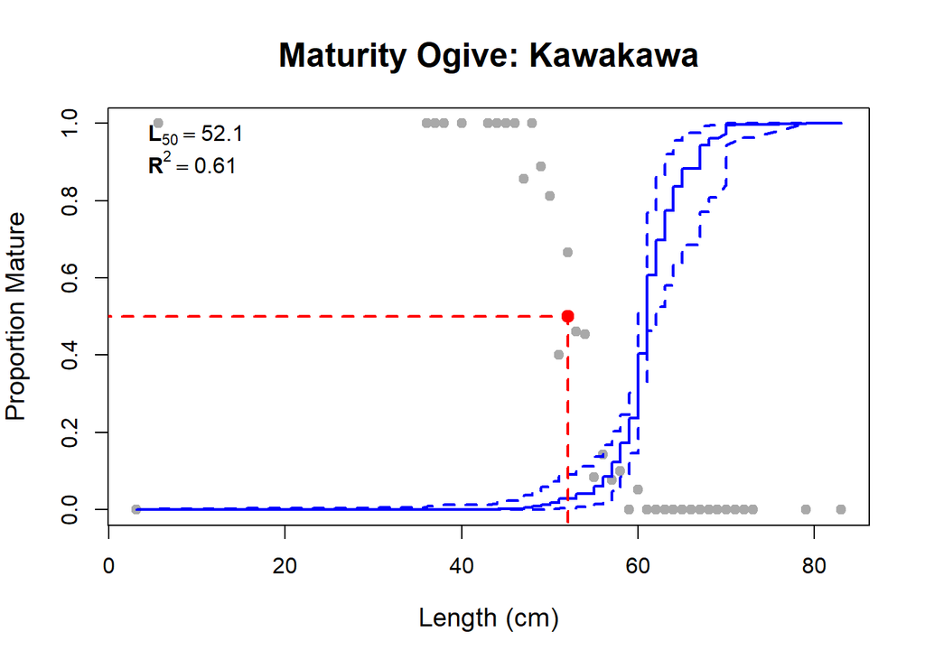

```
Size at morphometric maturity = 52.1
Confidence intervals = 50.4 - 53.1
Rsquare = 0.61
```

```r
kaw_ogive_fq |>
    plot(
    main = 'Maturity Ogive: Kawakawa',
    xlab = 'Length (cm)',
    ylab = 'Proportion Mature',
    cex.main = 1.5,
    cex.lab = 1.2,
    cex.axis = 1,
    onlyOgive = TRUE
)
```

### Jack Mackerel

**What we’re doing:** Analyze maturity for Jack Mackerel (JAC).

```r
jac = lw |>
    filter(fish_type_code == 'JAC')
```

```r
## Partitioning with Linear Discriminant Analysis
classified_jac <- jac |>
  classify_mature(
    varNames = c("length_cm", "weight_kg"),
    varSex = NULL,
    selectSex = NULL,
    method = "ld"
  )
```

```
all individuals were used in the analysis
```

```r
classified_jac
```

```
Number in juvenile group = 153

Number in adult group = 136

--------------------------------------------------------
1) Linear regression for juveniles

Call:
glm(formula = y ~ x, data = juv)

Coefficients:
             Estimate Std. Error t value Pr(>|t|)
(Intercept) -1.182173   0.190937  -6.191 5.37e-09 ***
x            0.067762   0.003261  20.778  < 2e-16 ***
---
Signif. codes:  0 '***' 0.001 '**' 0.01 '*' 0.05 '.' 0.1 ' ' 1

(Dispersion parameter for gaussian family taken to be 0.2652843)

    Null deviance: 154.583  on 152  degrees of freedom
Residual deviance:  40.058  on 151  degrees of freedom
AIC: 235.16

Number of Fisher Scoring iterations: 2

--------------------------------------------------------
2) Linear regression for adults

Call:
glm(formula = y ~ x, data = adt)

Coefficients:
            Estimate Std. Error t value Pr(>|t|)
(Intercept) -9.17278    1.39456  -6.578 9.84e-10 ***
x            0.20412    0.01765  11.566  < 2e-16 ***
---
Signif. codes:  0 '***' 0.001 '**' 0.01 '*' 0.05 '.' 0.1 ' ' 1

(Dispersion parameter for gaussian family taken to be 5.237425)

    Null deviance: 1402.45  on 135  degrees of freedom
Residual deviance:  701.81  on 134  degrees of freedom
AIC: 615.13

Number of Fisher Scoring iterations: 2

--------------------------------------------------------
3) Difference between slopes (ANCOVA)
               Estimate Std. Error   t value     Pr(>|t|)
(Intercept) -1.18217347 0.59810330 -1.976537 4.905786e-02
x            0.06776167 0.01021588  6.632976 1.649592e-10
mature      -7.99061056 1.15078904 -6.943593 2.587095e-11
x:mature     0.13635474 0.01609834  8.470111 1.322469e-15
[1] "slopes are different"
```

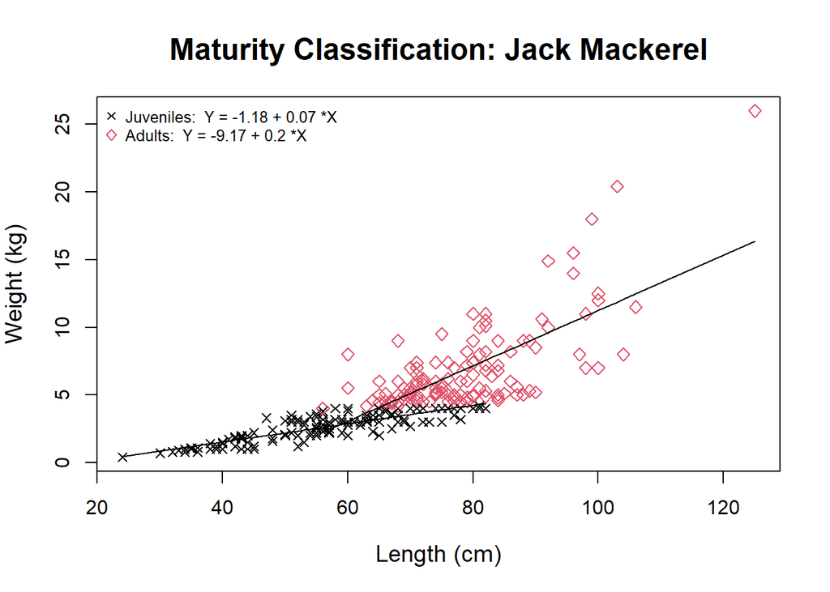

```r
classified_jac |>
  plot(
    main = 'Maturity Classification: Jack Mackerel',
    xlab = 'Length (cm)',
    ylab = 'Weight (kg)',
    cex.main = 1.5,
    cex.lab = 1.2,
    cex.axis = 1
  )
```

```r
jac_ogive_fq <- morph_mature(
    data = classified_jac,
    method = "fq",
    niter = 1000
)
```

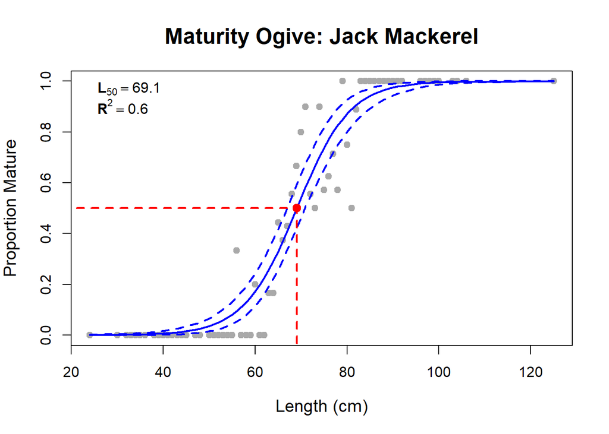

```
Size at morphometric maturity = 69.1
Confidence intervals = 67 - 70.8
Rsquare = 0.6
```

```r
jac_ogive_fq |>
    plot(
    main = 'Maturity Ogive: Jack Mackerel',
    xlab = 'Length (cm)',
    ylab = 'Proportion Mature',
    cex.main = 1.5,
    cex.lab = 1.2,
    cex.axis = 1,
    onlyOgive = TRUE
)
```

### Longtail Tuna

**What we’re doing:** Analyze maturity for Longtail Tuna (LOT).

```r
lot = lw |>
    filter(fish_type_code == 'LOT')
```

```r
## Partitioning with Linear Discriminant Analysis
classified_lot <- lot |>
  classify_mature(
    varNames = c("length_cm", "weight_kg"),
    varSex = NULL,
    selectSex = NULL,
    method = "ld"
  )
```

```
all individuals were used in the analysis
```

```r
classified_lot
```

```
Number in juvenile group = 167

Number in adult group = 119

--------------------------------------------------------
1) Linear regression for juveniles

Call:
glm(formula = y ~ x, data = juv)

Coefficients:
             Estimate Std. Error t value Pr(>|t|)
(Intercept) -2.036814   0.435406  -4.678    6e-06 ***
x            0.089616   0.006362  14.087   <2e-16 ***
---
Signif. codes:  0 '***' 0.001 '**' 0.01 '*' 0.05 '.' 0.1 ' ' 1

(Dispersion parameter for gaussian family taken to be 0.445462)

    Null deviance: 161.896  on 166  degrees of freedom
Residual deviance:  73.501  on 165  degrees of freedom
AIC: 342.87

Number of Fisher Scoring iterations: 2

--------------------------------------------------------
2) Linear regression for adults

Call:
glm(formula = y ~ x, data = adt)

Coefficients:
            Estimate Std. Error t value Pr(>|t|)
(Intercept) -6.67824    1.21192   -5.51 2.16e-07 ***
x            0.16794    0.01429   11.76  < 2e-16 ***
---
Signif. codes:  0 '***' 0.001 '**' 0.01 '*' 0.05 '.' 0.1 ' ' 1

(Dispersion parameter for gaussian family taken to be 1.98903)

    Null deviance: 507.56  on 118  degrees of freedom
Residual deviance: 232.72  on 117  degrees of freedom
AIC: 423.52

Number of Fisher Scoring iterations: 2

--------------------------------------------------------
3) Difference between slopes (ANCOVA)
               Estimate  Std. Error   t value     Pr(>|t|)
(Intercept) -2.03681376 0.679798367 -2.996203 2.976712e-03
x            0.08961564 0.009932577  9.022395 2.926832e-17
mature      -4.64142846 1.124263924 -4.128415 4.815380e-05
x:mature     0.07832407 0.014494373  5.403757 1.389924e-07
[1] "slopes are different"
```

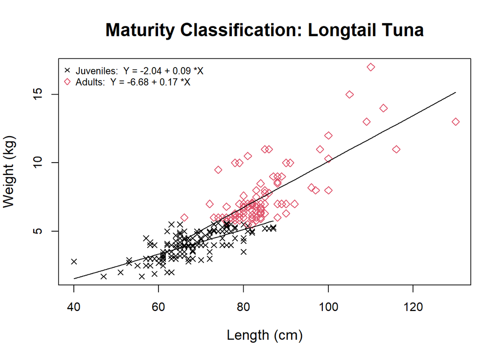

```r
classified_lot |>
  plot(
    main = 'Maturity Classification: Longtail Tuna',
    xlab = 'Length (cm)',
    ylab = 'Weight (kg)',
    cex.main = 1.5,
    cex.lab = 1.2,
    cex.axis = 1
  )
```

```r
lot_ogive_fq <- morph_mature(
    data = classified_lot,
    method = "fq",
    niter = 1000
)
```

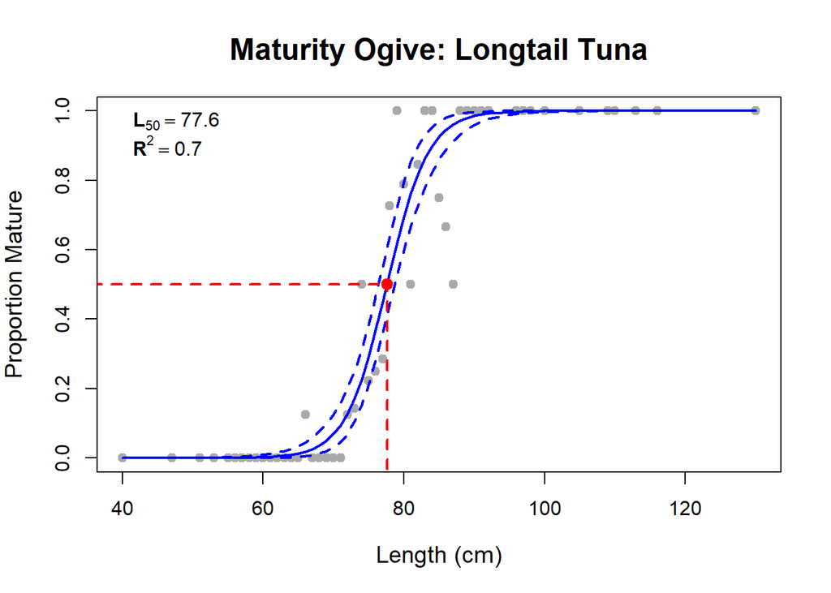

```
Size at morphometric maturity = 77.6
Confidence intervals = 76.4 - 78.7
Rsquare = 0.7
```

```r
lot_ogive_fq |>
    plot(
    main = 'Maturity Ogive: Longtail Tuna',
    xlab = 'Length (cm)',
    ylab = 'Proportion Mature',
    cex.main = 1.5,
    cex.lab = 1.2,
    cex.axis = 1,
    onlyOgive = TRUE
)
```

### Mahi-mahi

**What we’re doing:** Analyze maturity for Mahi-mahi (MAH).

```r
mah = lw |>
    filter(fish_type_code == 'MAH')
```

```r
## Partitioning with Linear Discriminant Analysis
classified_mah <- mah |>
  classify_mature(
    varNames = c("length_cm", "weight_kg"),
    varSex = NULL,
    selectSex = NULL,
    method = "ld"
  )
```

```
all individuals were used in the analysis
```

```r
classified_mah
```

```
Number in juvenile group = 65

Number in adult group = 192

--------------------------------------------------------
1) Linear regression for juveniles

Call:
glm(formula = y ~ x, data = juv)

Coefficients:
            Estimate Std. Error t value Pr(>|t|)
(Intercept) 45.43976    5.64328   8.052 2.89e-11 ***
x           -0.29975    0.05052  -5.933 1.38e-07 ***
---
Signif. codes:  0 '***' 0.001 '**' 0.01 '*' 0.05 '.' 0.1 ' ' 1

(Dispersion parameter for gaussian family taken to be 49.80705)

    Null deviance: 4891.1  on 64  degrees of freedom
Residual deviance: 3137.8  on 63  degrees of freedom
AIC: 442.46

Number of Fisher Scoring iterations: 2

--------------------------------------------------------
2) Linear regression for adults

Call:
glm(formula = y ~ x, data = adt)

Coefficients:
             Estimate Std. Error t value Pr(>|t|)
(Intercept) -0.631788   0.528260  -1.196    0.233
x            0.065457   0.006148  10.647   <2e-16 ***
---
Signif. codes:  0 '***' 0.001 '**' 0.01 '*' 0.05 '.' 0.1 ' ' 1

(Dispersion parameter for gaussian family taken to be 1.039763)

    Null deviance: 315.41  on 191  degrees of freedom
Residual deviance: 197.55  on 190  degrees of freedom
AIC: 556.35

Number of Fisher Scoring iterations: 2

--------------------------------------------------------
3) Difference between slopes (ANCOVA)
               Estimate Std. Error   t value     Pr(>|t|)
(Intercept)  45.4397593 2.90335517  15.65078 4.501646e-39
x            -0.2997497 0.02599251 -11.53215 5.259435e-25
mature      -46.0715471 3.45944011 -13.31763 5.071576e-31
x:mature      0.3652065 0.03398368  10.74653 1.951909e-22
[1] "slopes are different"
```

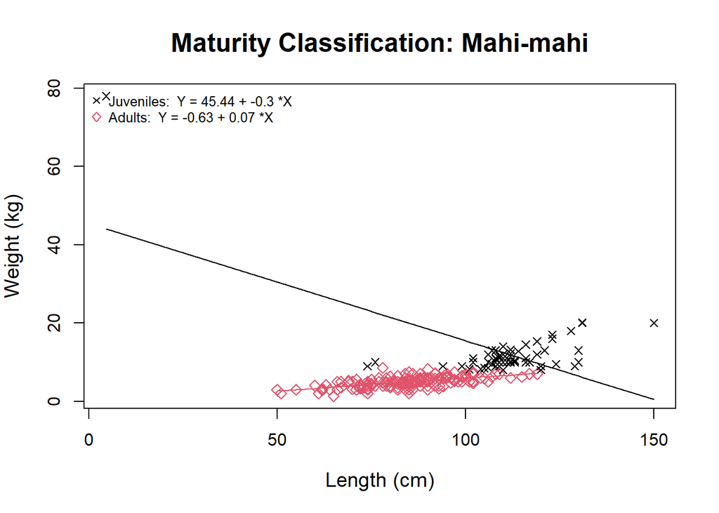

```r
classified_mah |>
  plot(
    main = 'Maturity Classification: Mahi-mahi',
    xlab = 'Length (cm)',
    ylab = 'Weight (kg)',
    cex.main = 1.5,
    cex.lab = 1.2,
    cex.axis = 1
  )
```

```r
mah_ogive_fq <- morph_mature(
    data = classified_mah,
    method = "fq",
    niter = 1000
)
```

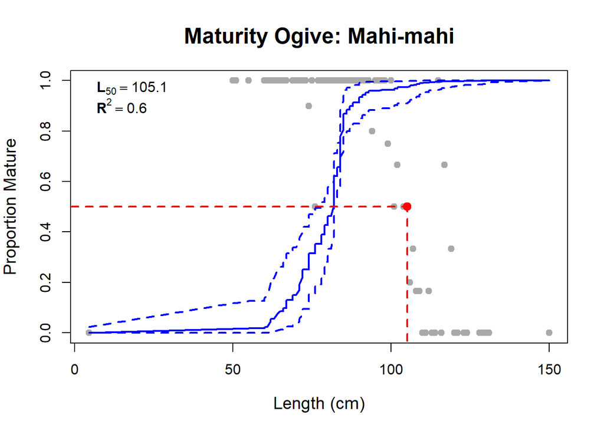

```
Size at morphometric maturity = 105.1
Confidence intervals = 102.8 - 108.8
Rsquare = 0.6
```

```r
mah_ogive_fq |>
    plot(
    main = 'Maturity Ogive: Mahi-mahi',
    xlab = 'Length (cm)',
    ylab = 'Proportion Mature',
    cex.main = 1.5,
    cex.lab = 1.2,
    cex.axis = 1,
    onlyOgive = TRUE
)
```

### Chub Mackerel

**What we’re doing:** Analyze maturity for Chub Mackerel (SCH).

```r
sch = lw |>
    filter(fish_type_code == 'SCH')
```

```r
## Partitioning with Linear Discriminant Analysis
classified_sch <- sch |>
  classify_mature(
    varNames = c("length_cm", "weight_kg"),
    varSex = NULL,
    selectSex = NULL,
    method = "ld"
  )
```

```
all individuals were used in the analysis
```

```r
classified_sch
```

```
Number in juvenile group = 178

Number in adult group = 49

--------------------------------------------------------
1) Linear regression for juveniles

Call:
glm(formula = y ~ x, data = juv)

Coefficients:
            Estimate Std. Error t value Pr(>|t|)
(Intercept) 0.264379   0.396674   0.666    0.506
x           0.026073   0.004938   5.280 3.78e-07 ***
---
Signif. codes:  0 '***' 0.001 '**' 0.01 '*' 0.05 '.' 0.1 ' ' 1

(Dispersion parameter for gaussian family taken to be 0.2914736)

    Null deviance: 59.424  on 177  degrees of freedom
Residual deviance: 51.299  on 176  degrees of freedom
AIC: 289.69

Number of Fisher Scoring iterations: 2

--------------------------------------------------------
2) Linear regression for adults

Call:
glm(formula = y ~ x, data = adt)

Coefficients:
              Estimate Std. Error t value Pr(>|t|)
(Intercept) -10.555467   0.831908  -12.69   <2e-16 ***
x             0.176104   0.008501   20.71   <2e-16 ***
---
Signif. codes:  0 '***' 0.001 '**' 0.01 '*' 0.05 '.' 0.1 ' ' 1

(Dispersion parameter for gaussian family taken to be 1.578051)

    Null deviance: 751.300  on 48  degrees of freedom
Residual deviance:  74.168  on 47  degrees of freedom
AIC: 165.37

Number of Fisher Scoring iterations: 2

--------------------------------------------------------
3) Difference between slopes (ANCOVA)
               Estimate  Std. Error    t value     Pr(>|t|)
(Intercept)   0.2643791 0.551121681   0.479711 6.319031e-01
x             0.0260733 0.006861272   3.800067 1.866385e-04
mature      -10.8198461 0.741946828 -14.583048 2.827909e-34
x:mature      0.1500305 0.008534969  17.578327 5.507599e-44
[1] "slopes are different"
```

**What we’re doing:** Visualize the classification results for Chub Mackerel.

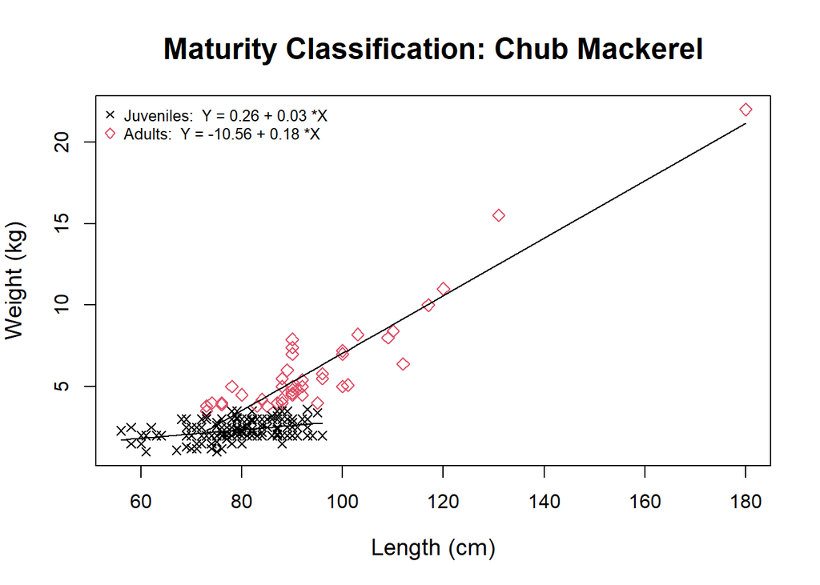

```r
classified_sch |>
  plot(
    main = 'Maturity Classification: Chub Mackerel',
    xlab = 'Length (cm)',
    ylab = 'Weight (kg)',
    cex.main = 1.5,
    cex.lab = 1.2,
    cex.axis = 1
  )
```

```r
sch_ogive_fq <- morph_mature(
    data = classified_sch,
    method = "fq",
    niter = 1000
)
```

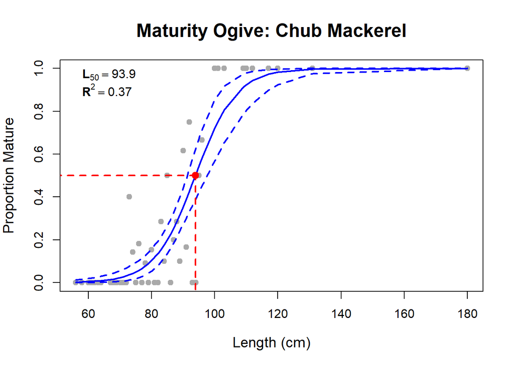

```
Size at morphometric maturity = 93.9
Confidence intervals = 91.3 - 97.7
Rsquare = 0.37
```

```r
sch_ogive_fq |>
    plot(
    main = 'Maturity Ogive: Chub Mackerel',
    xlab = 'Length (cm)',
    ylab = 'Proportion Mature',
    cex.main = 1.5,
    cex.lab = 1.2,
    cex.axis = 1,
    onlyOgive = TRUE
)
```

# Combined Maturity Ogives

**What we’re doing:** Automate the entire analysis for all species and create a multi-panel figure for easy visual comparison of maturity schedules across species.

**Why combine them:** Side-by-side comparison reveals differences in maturity schedules between species, which is important for species-specific management strategies.

```
all individuals were used in the analysis
```

```
formula: Y = 1/1+exp-(A + B*X)
```

```
Size at morphometric maturity = 94.3
Confidence intervals = 92.4 - 96.5
Rsquare = 0.89all individuals were used in the analysis
```

```
formula: Y = 1/1+exp-(A + B*X)
```

```
Size at morphometric maturity = 59.2
Confidence intervals = 58.4 - 60.2
Rsquare = 0.74all individuals were used in the analysis
```

```
formula: Y = 1/1+exp-(A + B*X)
```

```
Size at morphometric maturity = 52.1
Confidence intervals = 50.4 - 53.1
Rsquare = 0.61all individuals were used in the analysis

formula: Y = 1/1+exp-(A + B*X)
```

```
Size at morphometric maturity = 69.1
Confidence intervals = 67 - 70.8
Rsquare = 0.6all individuals were used in the analysis

formula: Y = 1/1+exp-(A + B*X)
```

```
Size at morphometric maturity = 77.6
Confidence intervals = 76.4 - 78.7
Rsquare = 0.7all individuals were used in the analysis

formula: Y = 1/1+exp-(A + B*X)
```

```
Size at morphometric maturity = 105.1
Confidence intervals = 102.8 - 108.8
Rsquare = 0.6all individuals were used in the analysis

formula: Y = 1/1+exp-(A + B*X)
```

```
Size at morphometric maturity = 93.9
Confidence intervals = 91.3 - 97.7
Rsquare = 0.37all individuals were used in the analysis
```

```
formula: Y = 1/1+exp-(A + B*X)
```

```
Size at morphometric maturity = 62.5
Confidence intervals = 62.5 - 63
Rsquare = 1
```

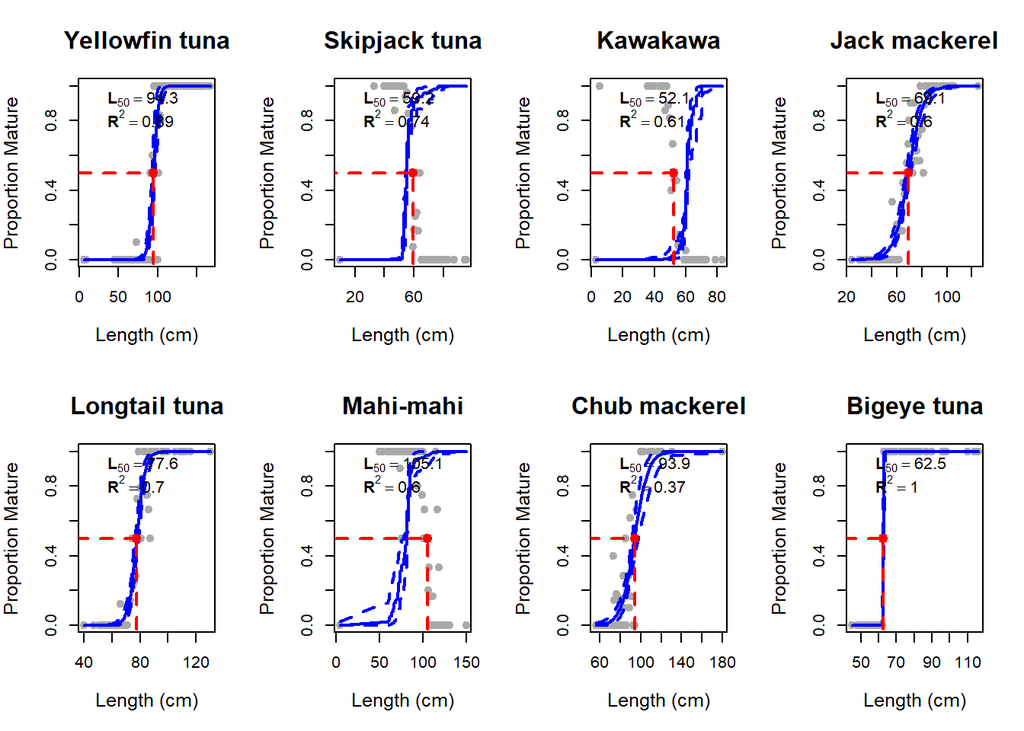

Figure 1: Maturity ogives for eight commercially important fish species from Somalian waters. Each panel displays the logistic regression curve representing the proportion of mature individuals as a function of their length (cm). The maturity classification was determined using a morphological approach based on length-weight data.

```r
par(mfrow = c(2, 4))

ogive = list()
lf_tb = list()

for (i in 1:length(fishes)){

    classified = lw |>
      ## select species
      filter(fish_type_code == fish_name$FAO_Code[i]) |>
      # classify using linear discriminant analysis
      classify_mature(
        varNames = c("length_cm", "weight_kg"),
        varSex = NULL,
        selectSex = NULL,
        method = "ld"
      )

    # fit maturity ogive with 1000 bootstrap samples
    morph = classified |>
      morph_mature(
        method = "fq",
        niter = 1000
    )

    ogive[[i]] = morph

    # Extract and store L50 and other parameters
    lf_tb[[i]] = morph |>
        print() |>
        as.data.frame() |>
        as_tibble() |>
        mutate(Freq = as.numeric(Freq)) |>
        pivot_wider(names_from = Var1 , values_from  = Freq) |>
        mutate(
          species = fish_name$English_Name[i],
          scientific = fish_name$Scientific_Name[i]
          ) |>
        slice(1)

    # Plot maturity ogive for this species
    morph |>
        plot(
        main = paste(fish_name$English_Name[i], sep = " "),
        xlab = 'Length (cm)',
        ylab = 'Proportion Mature',
        cex.main = 1.5,
        cex.lab = 1.2,
        cex.axis = 1,
        onlyOgive = TRUE
    )
}
```

# Summary Table of Results